# sklearn.datasets.make_classification

**sklearn.datasets.make_classification(*n_samples=100*, *n_features=20*, *, *n_informative=2*, *n_redundant=2*, *n_repeated=0*, *n_classes=2*, *n_clusters_per_class=2*, *weights=None*, *flip_y=0.01*, *class_sep=1.0*, *hypercube=True*, *shift=0.0*, *scale=1.0*, *shuffle=True*, *random_state=None*)[[source]](https://github.com/scikit-learn/scikit-learn/blob/f3f51f9b6/sklearn/datasets/_samples_generator.py#L40)**

Generate a random n-class classification problem.

This initially creates clusters of points normally distributed (std=1) about vertices of an `n_informative`-dimensional hypercube with sides of length `2*class_sep` and assigns an equal number of clusters to each class. It introduces interdependence between these features and adds various types of further noise to the data.

Without shuffling, `X` horizontally stacks features in the following order: the primary `n_informative` features, followed by `n_redundant` linear combinations of the informative features, followed by `n_repeated` duplicates, drawn randomly with replacement from the informative and redundant features. The remaining features are filled with random noise. Thus, without shuffling, all useful features are contained in the columns `X[:, :n_informative + n_redundant + n_repeated]`.

Read more in the [User Guide](https://scikit-learn.org/1.1/datasets/sample_generators.html#sample-generators).

**Parameters:**

**n_samples**int, default=100**

The number of samples.

**n_features**int, default=20**

The total number of features. These comprise `n_informative` informative features, `n_redundant` redundant features, `n_repeated` duplicated features and `n_features-n_informative-n_redundant-n_repeated` useless features drawn at random.

**n_informative**int, default=2**

The number of informative features. Each class is composed of a number of gaussian clusters each located around the vertices of a hypercube in a subspace of dimension `n_informative`. For each cluster, informative features are drawn independently from N(0, 1) and then randomly linearly combined within each cluster in order to add covariance. The clusters are then placed on the vertices of the hypercube.

**n_redundant**int, default=2**

The number of redundant features. These features are generated as random linear combinations of the informative features.

**n_repeated**int, default=0**

The number of duplicated features, drawn randomly from the informative and the redundant features.

**n_classes**int, default=2**

The number of classes (or labels) of the classification problem.

**n_clusters_per_class**int, default=2**

The number of clusters per class.

**weights**array-like of shape (n_classes,) or (n_classes - 1,), default=None**

The proportions of samples assigned to each class. If None, then classes are balanced. Note that if `len(weights) == n_classes - 1`, then the last class weight is automatically inferred. More than `n_samples` samples may be returned if the sum of `weights` exceeds 1. Note that the actual class proportions will not exactly match `weights` when `flip_y` isn’t 0.

**flip_y**float, default=0.01**

The fraction of samples whose class is assigned randomly. Larger values introduce noise in the labels and make the classification task harder. Note that the default setting flip_y > 0 might lead to less than `n_classes` in y in some cases.

**class_sep**float, default=1.0**

The factor multiplying the hypercube size. Larger values spread out the clusters/classes and make the classification task easier.

**hypercube**bool, default=True**

If True, the clusters are put on the vertices of a hypercube. If False, the clusters are put on the vertices of a random polytope.

**shift**float, ndarray of shape (n_features,) or None, default=0.0**

Shift features by the specified value. If None, then features are shifted by a random value drawn in [-class_sep, class_sep].

**scale**float, ndarray of shape (n_features,) or None, default=1.0**

Multiply features by the specified value. If None, then features are scaled by a random value drawn in [1, 100]. Note that scaling happens after shifting.

**shuffle**bool, default=True**

Shuffle the samples and the features.

**random_state**int, RandomState instance or None, default=None**

Determines random number generation for dataset creation. Pass an int for reproducible output across multiple function calls. See [Glossary](https://scikit-learn.org/1.1/glossary.html#term-random_state).

**Returns:**

**X**ndarray of shape (n_samples, n_features)**

The generated samples.

**y**ndarray of shape (n_samples,)**

The integer labels for class membership of each sample.

See also

**`make_blobs`**

Simplified variant.

**`make_multilabel_classification`**

Unrelated generator for multilabel tasks.

#### Notes

The algorithm is adapted from Guyon [1] and was designed to generate the “Madelon” dataset.

#### References

[1]

I. Guyon, “Design of experiments for the NIPS 2003 variable selection benchmark”, 2003.

## Examples using `sklearn.datasets.make_classification`

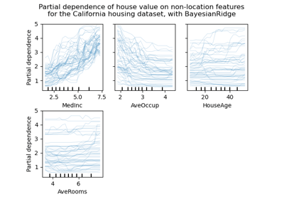

Release Highlights for scikit-learn 0.24

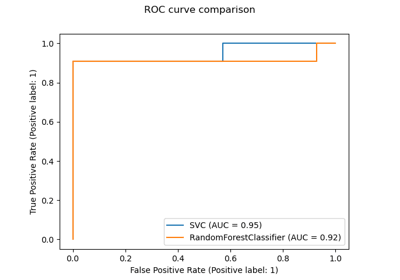

Release Highlights for scikit-learn 0.22

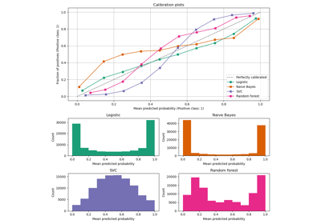

Comparison of Calibration of Classifiers

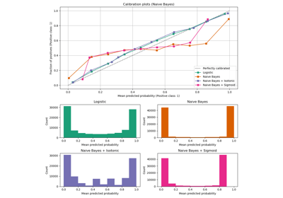

Probability Calibration curves

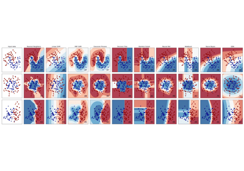

Classifier comparison

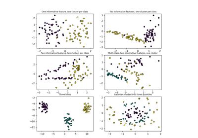

Plot randomly generated classification dataset

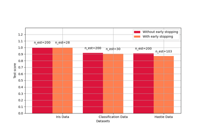

Early stopping of Gradient Boosting

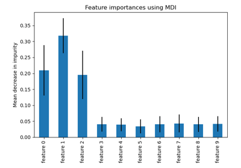

Feature importances with a forest of trees

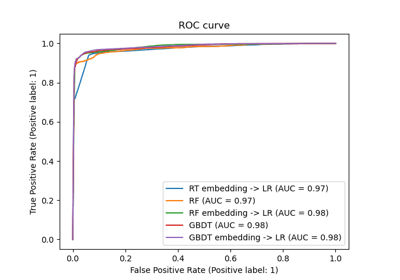

Feature transformations with ensembles of trees

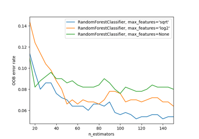

OOB Errors for Random Forests

[figure not shown]

Pipeline ANOVA SVM

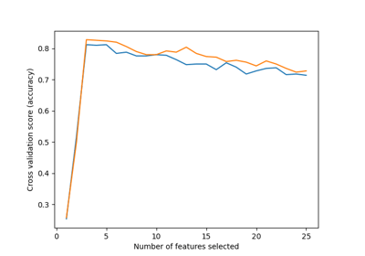

Recursive feature elimination with cross-validation

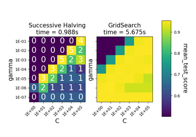

Comparison between grid search and successive halving

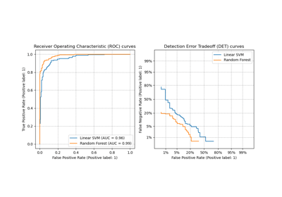

Detection error tradeoff (DET) curve

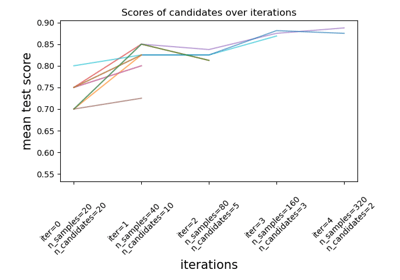

Successive Halving Iterations

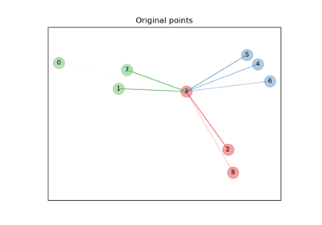

Neighborhood Components Analysis Illustration

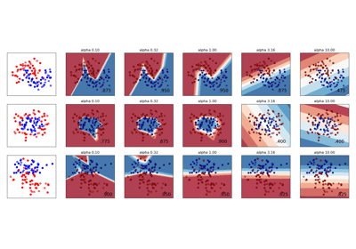

Varying regularization in Multi-layer Perceptron

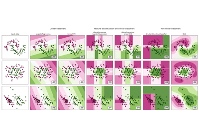

Feature discretization

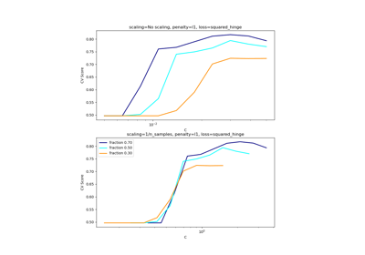

Scaling the regularization parameter for SVCs